# day2_SCHMITZ.R

laura

2025-11-30

**Setup**

**`Loading packages`**

```r
require(tidyverse)
require(limma)
```

```r
require(ComplexHeatmap)
```

**`Loading data`**

```r
setwd("G:/My Drive/. PLUS/. MASTER Medical Biology/ALL COURSES/UE Hands-on Biomedical Data – Resources and Analysis Tools (4.5 ECTS)/Teil Fortelny")
data <- readRDS("data.RDS")
metadata <- readRDS("design.RDS")
gmap <- readRDS("gmap.RDS")
```

**2.1) For all three objects above, answer the following questions:**

**What type of object is it?** `data` is a **matrix**; `metadata` and `gmaps` are **data frames**.

```r
class(data)
```

```
## [1] "matrix" "array"
```

```r
class(metadata)
```

```
## [1] "data.frame"
```

```r
class(gmap)
```

```
## [1] "data.frame"
```

**How many rows and columns are this object?** `data` has 22055 rows and 230 columns; `metadata` has 230 rows and 3 columns; `gmaps` has 21923 rows and 2 columns.

```r
dim(data)
```

```
## [1] 22055   230
```

```r
dim(metadata)
```

```
## [1] 230   3
```

```r
dim(gmap)
```

```
## [1] 21923     2
```

**What information is contained in rows and columns?** `data` contains gene expression data for immune cells of the epithelium, endothelium and fibroblasts isolated from different organs.

```r
str(data)
```

```
##  num [1:22055, 1:230] 1668 0 0 0 0 ...
##  - attr(*, "dimnames")=List of 2
##   ..$ : chr [1:22055] "ENSMUSG00000000001" "ENSMUSG00000000003" "ENSMUSG00000000028" "ENSMUSG00000000037" ...
##   ..$ : chr [1:230] "Liver_Fibroblasts_IL6_RNA_2" "Liver_Fibroblasts_TGFb_RNA_3" "Spleen_Fibroblasts_IFNa_RNA_1" "Spleen_Epithelium_TGFb_RNA_3" ...
```

`metadata` describes the experimental conditions of each sample

```r
str(metadata)
```

```
## 'data.frame':    230 obs. of  3 variables:
##  $ cell_type: chr  "GP38posCD31neg" "GP38posCD31neg" "GP38posCD31neg" "EPCAMpos" ...
##  $ stimulus : chr  "IL6" "TGFb" "IFNa" "TGFb" ...
##  $ organ    : chr  "Liver" "Liver" "Spleen" "Spleen" ...
```

#’`gmap` maps each gene to standard identifiers

```r
str(gmap)
```

```
## 'data.frame':    21923 obs. of  2 variables:
##  $ external_gene_name: chr  "Gnai3" "Pbsn" "Cdc45" "Scml2" ...
##  $ gene_unique       : chr  "Gnai3" "Pbsn" "Cdc45" "Scml2" ...
```

**Filtering metadata to liver fibroblasts (**Gp38 positive**) that were treated with **interferon alpha** or **PBS**

```r
metadata <- metadata %>%
  filter(
    grepl("GP38pos", cell_type),
    stimulus %in% c("IFNa", "PBS"),
    organ == "Liver"
  )
```

**Subsetting data matrix to the same samples in the updated metadata**

```r
data <- data[, colnames(data) %in% rownames(metadata)]
stopifnot(ncol(data) == nrow(metadata))
```

**I also changed the row names and order to make it visually better in the graphs:**

```r
rownames(metadata) <-
  rownames(metadata) |>
  (\(x) gsub("Liver_Fibroblasts_", "LF_", x))() |>
  (\(x) gsub("_RNA_", "_", x))()

colnames(data) <-
  colnames(data) |>
  (\(x) gsub("Liver_Fibroblasts_", "LF_", x))() |>
  (\(x) gsub("_RNA_", "_", x))()

head(metadata)
```

```
##                cell_type stimulus organ
## LF_IFNa_2 GP38posCD31neg     IFNa Liver
## LF_PBS_1  GP38posCD31neg      PBS Liver
## LF_IFNa_3 GP38posCD31neg     IFNa Liver
## LF_PBS_3  GP38posCD31neg      PBS Liver
## LF_IFNa_1 GP38posCD31neg     IFNa Liver
## LF_PBS_2  GP38posCD31neg      PBS Liver
```

```r
head(data)
```

```
##                    LF_IFNa_2 LF_PBS_1 LF_IFNa_3 LF_PBS_3 LF_IFNa_1 LF_PBS_2
## ENSMUSG00000000001         3     1981      7024      302         7        2
## ENSMUSG00000000003         0        0         0        0         0        0
## ENSMUSG00000000028         0        0         0        1         0        0
## ENSMUSG00000000037         0        0         0        1         0        0
## ENSMUSG00000000049      7602     3222     17104     1579         6       60
## ENSMUSG00000000056         0        1         0        0         1        0
```

**Correlation analysis**

**2.2) Provide the heatmap of the correlation matrix. Did you (or should you) remove the diagonal from the correlation matrix heatmap?**

Using the function `Heatmap()` (*≠ heatmap()!*) instead of `pheatpmap` this time, and deleting the diagonal 1s since they are not informative and disturb the color coding.

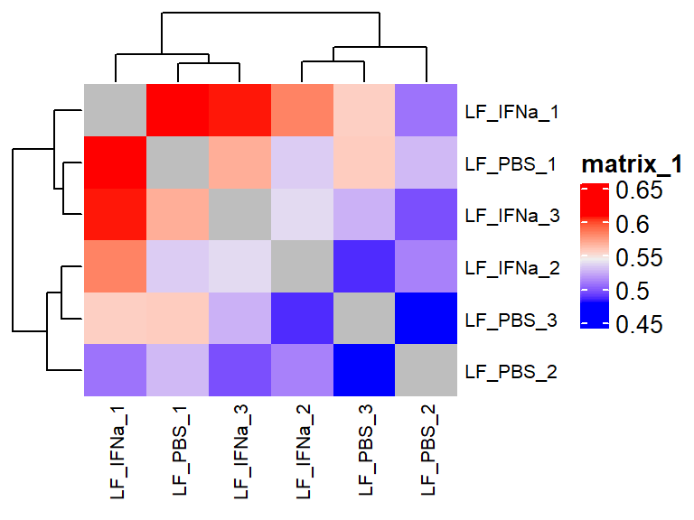

```r
corMT <- cor(data, method = "spearman")
diag(corMT) <- NA # removes the diagonal
Heatmap(corMT,
  row_names_gp = gpar(fontsize = 8),
  column_names_gp = gpar(fontsize = 8))
```

**`MDS Projection`**

This will transform the calculated correlations into distance measures and plot this in 2 dimensions.

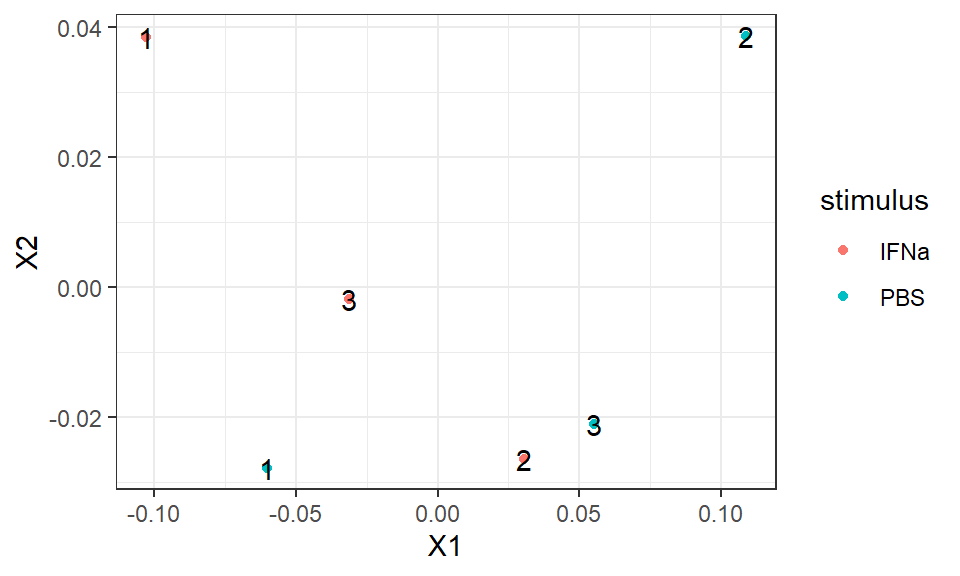

```r
data.frame(cmdscale(dist(2-corMT),eig=TRUE, k=2)$points) |>
  add_column(stimulus = metadata$stimulus) |>
  rownames_to_column("sample") |>
  mutate(sn = gsub("^.+?_(\\d)$", "\\1", sample)) |>  # This shortens the sample names to just the number at the end
  ggplot(aes(x=X1,y=X2)) +
  geom_point(aes(color=stimulus)) +
  geom_text(aes(label=sn)) +
  theme_bw()
```

**Differential expression and data normalization**

**2.3) Provide the heatmap for a model matrix comparing unstimulated (PBS) to stimulated (IFNa) samples. Which coefficient from the model matrix compares which groups?**

**Intercept** corresponds to **PBS** and **stimulus** corresponds to **IFNa**.

```r
metadata <- metadata |>
  mutate(stimulus = as.factor(stimulus)) |>
  mutate(stimulus = relevel(stimulus, ref = "PBS"))
levels(metadata$stimulus)
```

```
## [1] "PBS"  "IFNa"
```

```r
design_matrix <- model.matrix(~ stimulus, data = metadata)
```

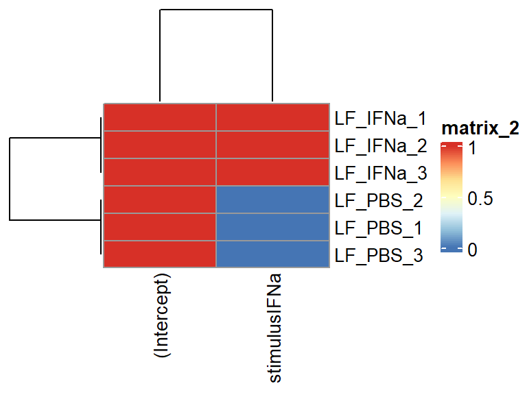

```r
pheatmap(design_matrix)
```

**2.4) Use `boxplot()` to plot the distributions of the first few (30) genes of the original matrix. Try both `boxplot(data[1:30,])` and `boxplot(t(data[1:30,]))`. What’s the difference?**

First, normalizing data by converting raw counts to **counts per million** and taking a **log transformation** to stabilize variance.

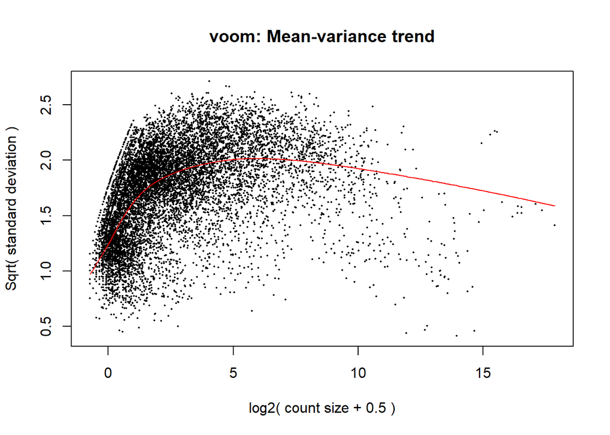

```r
dataVoom <- voom(data, design=design_matrix, plot = TRUE)
```

### Using **`boxplot(data[1:30,])`**

Shows the gene expression of the first 30 genes (rows) for all 6 samples/conditions (columns), without specifying which genes are expressed in which sample.

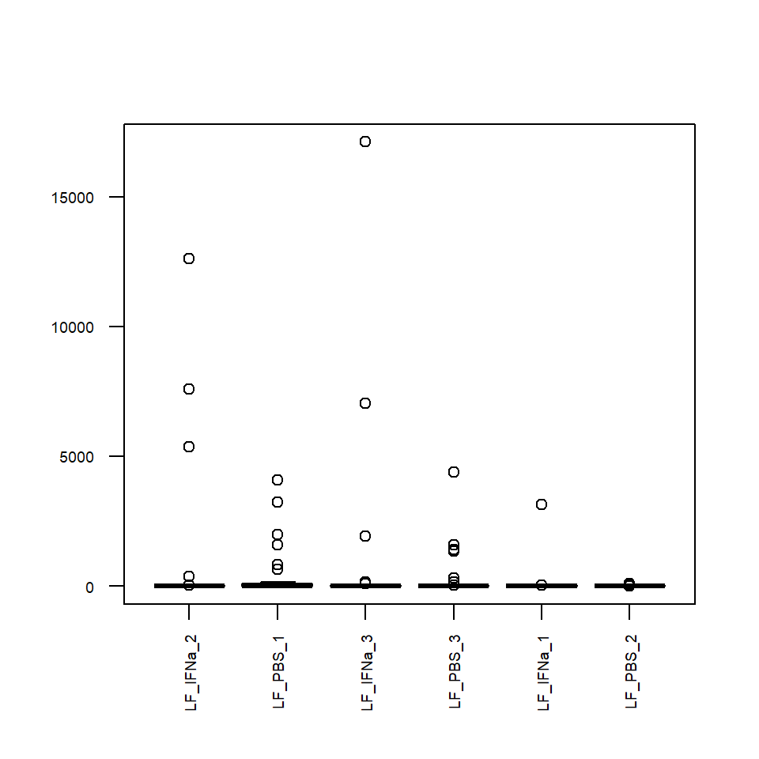

```r
boxplot(data[1:30,],
        las = 2, cex.axis = 0.6) # rotates x-axis and makes text smaller
```

### Using **`boxplot(t(data[1:30,]))`**

Transposes the x and y axis and shows the distribution of the first 30 genes across all 6 samples.

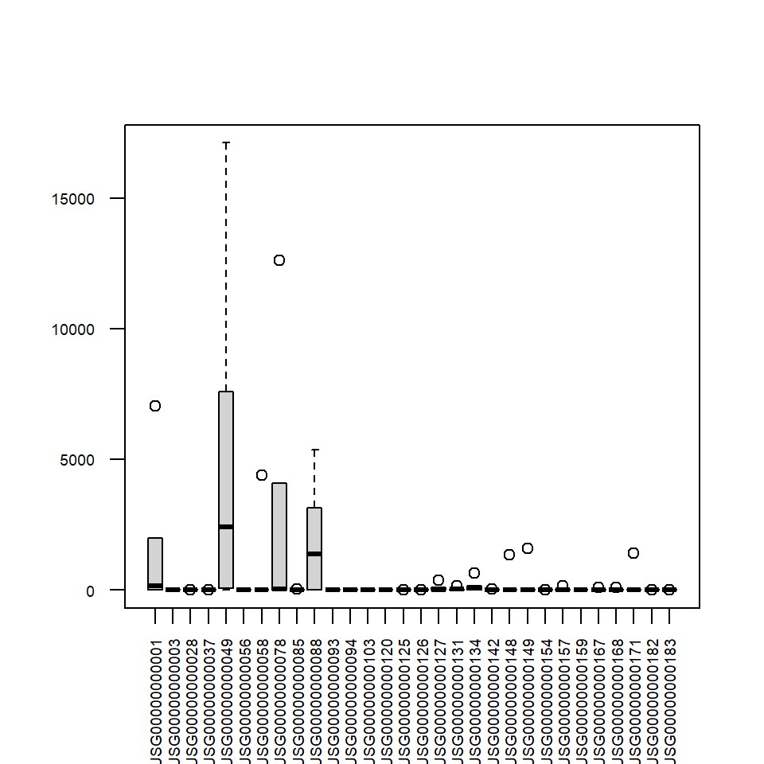

```r
boxplot(t(data[1:30,]),
        las = 2, cex.axis = 0.6)
```

**2.5) Now let’s look at the density of one gene (ENSMUSG00000000078) using three approaches: `plot(density(data[8,]))`, `plot(density(dataVoom$E[8,]))`, and `plot(density(log2(data[8,])))`. What’s the difference?**

Approach 1: distribution of **raw count** of gene #8 across all samples including the times this gene was counted zero times

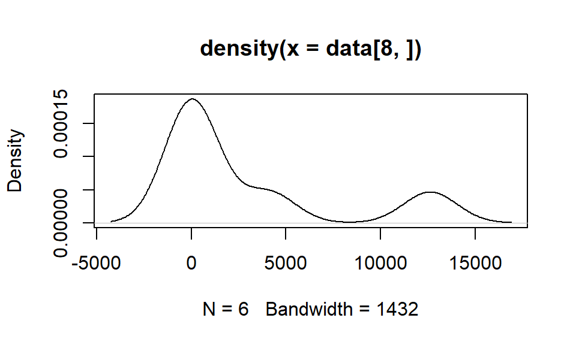

```r
plot(density(data[8,]))
```

Approach 2: **log-transform** of raw counts to stabilize variance across samples and reduce skewness, but not adjusted for library size.

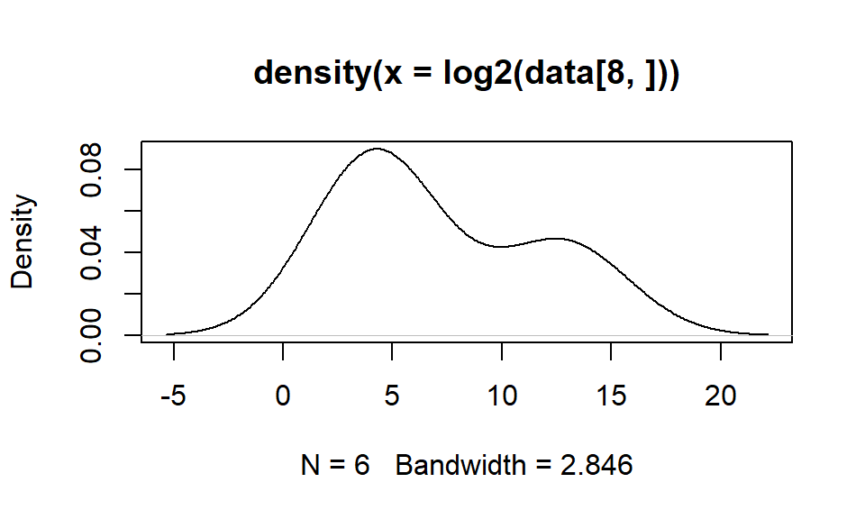

```r
plot(density(log2(data[8,])))
```

Approach 3: **voom-normalized** raw counts, i.e. log transformation + adjusted for library size.

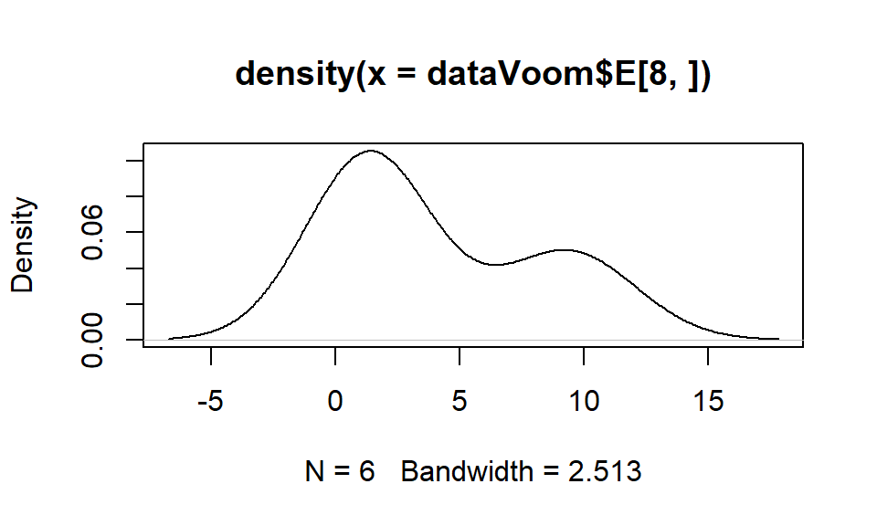

```r
plot(density(dataVoom$E[8,]))
```

**`Performing differential expression`**

```r
limmaFit <- lmFit(dataVoom, design=design_matrix)
limmaFit <- eBayes(limmaFit)
head(coef(limmaFit))
```

```
##                    (Intercept) stimulusIFNa
## ENSMUSG00000000001    4.105909   -1.6676793
## ENSMUSG00000000003   -3.622527   -0.7465299
## ENSMUSG00000000028   -2.921889   -1.4471673
## ENSMUSG00000000037   -2.921889   -1.4471673
## ENSMUSG00000000049    6.700237   -0.3369947
## ENSMUSG00000000056   -3.137492   -0.8623222
```

Extracting results:

```r
limmaRes <- list() # start an empty list
for(coefx in colnames(coef(limmaFit))){ # run a loop for each coefficient
  limmaRes[[coefx]] <- topTable(limmaFit, coef=coefx,number = Inf) # topTable returns the statistics of our genes. We then store the result of each coefficient in a list.
}
limmaRes <- bind_rows(limmaRes, .id = "coef") # bind_rows combines the results and stores the name of the coefficient in the column "coef"
limmaRes <- filter(limmaRes, coef != "(Intercept)") # then we keep all results except for the intercept
```

**Data Interpretation**

**2.6) Draw a volcano plot from the `limmaRes` object using a scatterplot `geom_point`. The point has many thousand points (genes). Can you overcome this overplotting by using transparency (e.g. `alpha=0.3`) or binning (e.g. `geom_hex`)?**

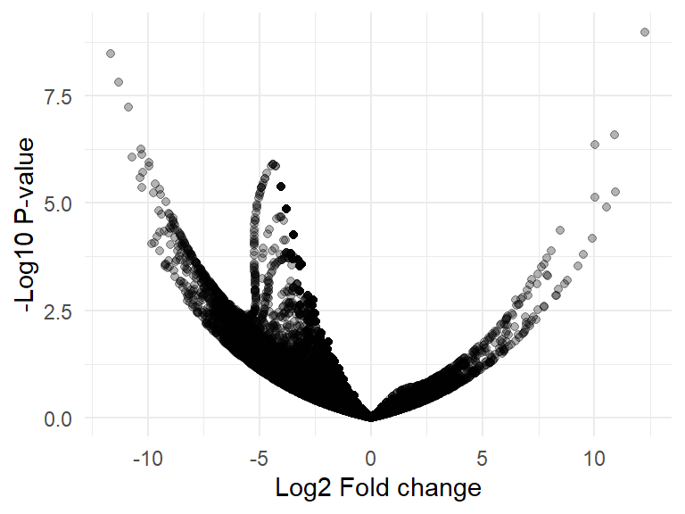

```r
ggplot(
  data = limmaRes,
  mapping = aes(x = logFC, y = -log10(P.Value))) +
  geom_point(alpha = 0.3) +
  theme_minimal() +
  labs(
    x = "Log2 Fold change",
    y = "-Log10 P-value"
  )
```

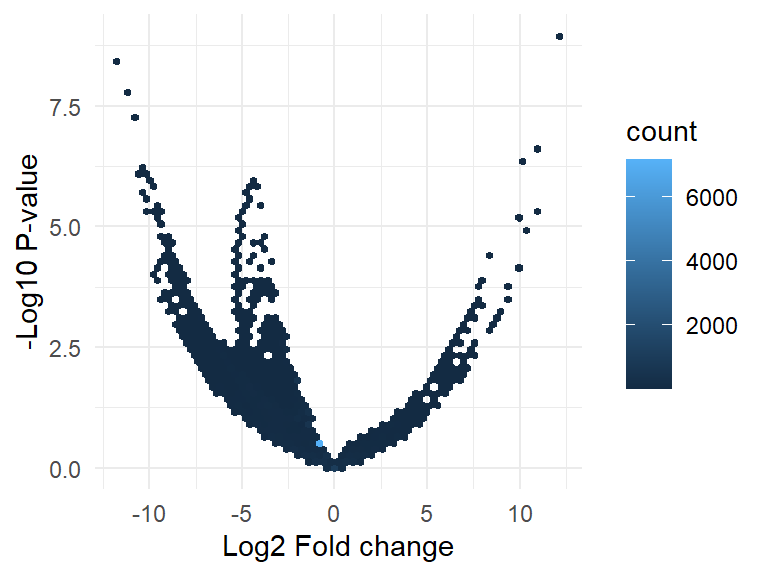

```r
ggplot(
  data = limmaRes,
  mapping = aes(x = logFC, y = -log10(P.Value))) +
  geom_hex(bins = 60) +
  theme_minimal() +
  labs(
    x = "Log2 Fold change",
    y = "-Log10 P-value"
  )
```

**2.7) Draw a p-value distribution using `geom_histogram`.**

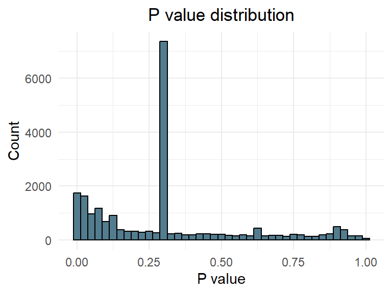

```r
ggplot(limmaRes,
  aes(x = P.Value)) +
  geom_histogram(binwidth = 0.025, fill = "#537C8E", color = "#000000")  +
  theme_minimal() +
  labs(
    title = "P value distribution",
    x = "P value",
    y = "Count") +
  theme(
    plot.title = element_text(hjust = 0.5)  # center the title
  )
```

**2.8) Is this distribution as expected? Use `fill=factor(floor(AveExpr)` to color the bins by the average expression level of each gene. Should you filter some genes? Which ones? If so, filter the genes, overwrite `limmaRes` with the result of the filtering and continue with the corrected data.**

**No!** There is an outlier (average expression = -4) that should be filtered out.

```r
limmaRes <- limmaRes |>
  filter(AveExpr > -4)
```

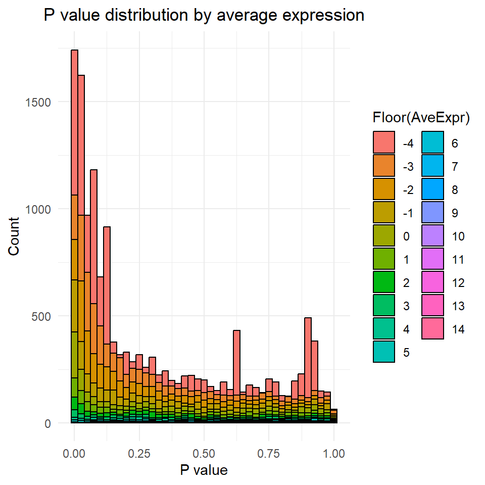

```r
ggplot(limmaRes,
       aes(x = P.Value, fill = factor(floor(AveExpr)))) +
  geom_histogram(binwidth = 0.025, color = "#000000")  +
  theme_minimal() +
  labs(
    title = "P value distribution by average expression",
    x = "P value",
    y = "Count",
    fill = "Floor(AveExpr)") +
  theme(
    plot.title = element_text(hjust = 0.5)  # center the title
  ) +
  guides(fill = guide_legend(ncol = 2))
```

**2.9) Report the number of tested and significant genes for the comparison of stimulated versus unstimulated.**

```r
# Counting number of tested genes:
limmaRes %>% count()
```

```
##       n
## 1 15001
```

```r
# Creating a table with genes that only change significantly between conditions, filtering out genes that are lowly expressed:
limmaResSig <- limmaRes %>%
  filter(adj.P.Val <= 0.05)

# Checking number of significant genes:
nrow(limmaResSig)
```

```
## [1] 482
```

**Visualizing results**

**2.10.1) Pick one gene with significant effects and a large absolute (negative or positive) log fold change from limmaResSig. Report the log fold change.**

> Chosen gene: **ENSMUSG00000020638**, with a log fold change of *12.27273*

```r
limmaResSig_largest_logFC <- limmaResSig %>%
  arrange(desc(logFC)) %>%
  select(logFC)
head(limmaResSig_largest_logFC)
```

```
##                       logFC
## ENSMUSG00000020638 12.27273
## ENSMUSG00000034459 10.93990
## ENSMUSG00000078920 10.92211
## ENSMUSG00000034855 10.54059
## ENSMUSG00000036216 10.04286
## ENSMUSG00000039910 10.03893
```

**2.10.2) Now create a table that we can use to plot this gene. To this end, modify the table metadata by adding the normalized expression of your gene of interest, taken from `dataVoom$E`, as a new column.**

```r
gene_of_interest <- dataVoom$E["ENSMUSG00000020638", ] # extracts normalized data of gene of interest

metadata <- metadata %>% mutate(gene_ENSMUSG00000020638 = gene_of_interest) # adds it as a new column in metadata
view(metadata)
```

**2.10.3) Generate a plot, where the x-axis is the stimulus (IFNa or PBS) and the y-axis is the expression of the gene. Does the observed difference on this plot fit to the log fold change?**

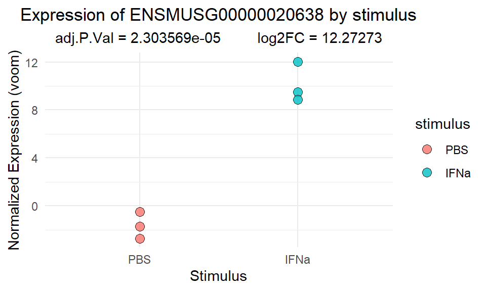

```r
ggplot(metadata, aes(x = stimulus, y = gene_ENSMUSG00000020638)) +
  geom_point(aes(fill = stimulus), shape = 21, color = "black", size = 3, alpha = 0.8) +
  theme_minimal() +
  labs(
    title = "Expression of ENSMUSG00000020638 by stimulus",
    subtitle = "adj.P.Val = 2.303569e-05         log2FC = 12.27273",
    x = "Stimulus",
    y = "Normalized Expression (voom)"
  ) +
  theme(
    plot.title = element_text(hjust = 0.5),  # center the title
    plot.subtitle = element_text(hjust = 0.5)  # center the subtitle
  )
```

> The plot does not show the exact **12.2** estimated for logFC in `limmaResSig` because limmaResSig gives an average of all IFNastimulus in different samples, while the plot uses the actual individual values from `dataVoom`,

**2.11.1) From `limmaResSig`, get the 30 genes with the greatest absolute logFC using the command `slice_max()`, which we saw on day 1, and save their ENSEMBL IDs, which are the row names of the table, in the object goi (genes of interest) using the function `row.names()`. What is the content of `goi`?**

```r
top30 <- limmaResSig %>%
  slice_max(order_by = abs(logFC), n = 30)
goi <- row.names(top30)
goi
```

```
##  [1] "ENSMUSG00000020638" "ENSMUSG00000010064" "ENSMUSG00000048170"
##  [4] "ENSMUSG00000034459" "ENSMUSG00000078920" "ENSMUSG00000035769"
##  [7] "ENSMUSG00000033107" "ENSMUSG00000034855" "ENSMUSG00000025609"
## [10] "ENSMUSG00000032239" "ENSMUSG00000035041" "ENSMUSG00000016942"
## [13] "ENSMUSG00000074063" "ENSMUSG00000036216" "ENSMUSG00000039910"
## [16] "ENSMUSG00000036529" "ENSMUSG00000021012" "ENSMUSG00000028270"
## [19] "ENSMUSG00000025137" "ENSMUSG00000046329" "ENSMUSG00000024387"
## [22] "ENSMUSG00000038510" "ENSMUSG00000037254" "ENSMUSG00000027332"
## [25] "ENSMUSG00000045932" "ENSMUSG00000061111" "ENSMUSG00000000631"
## [28] "ENSMUSG00000032249" "ENSMUSG00000039763" "ENSMUSG00000034243"
```

**2.11.2) Generate a heatmap of their gene expression from `dataVoom$E` using `Heatmap()`.**

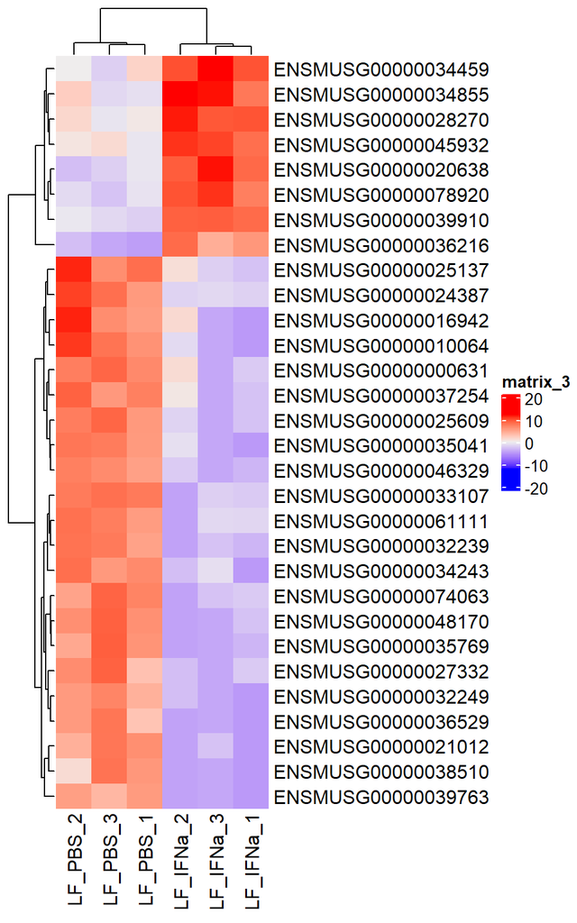

```r
expression_goi <- dataVoom$E[goi, ]
Heatmap(expression_goi)
```

**2.11.3) Scale the expression of all genes (rows of your matrix) using `t(scale(t(HM)))`, where HM is the matrix. See `t()` and `scale()` for details.**

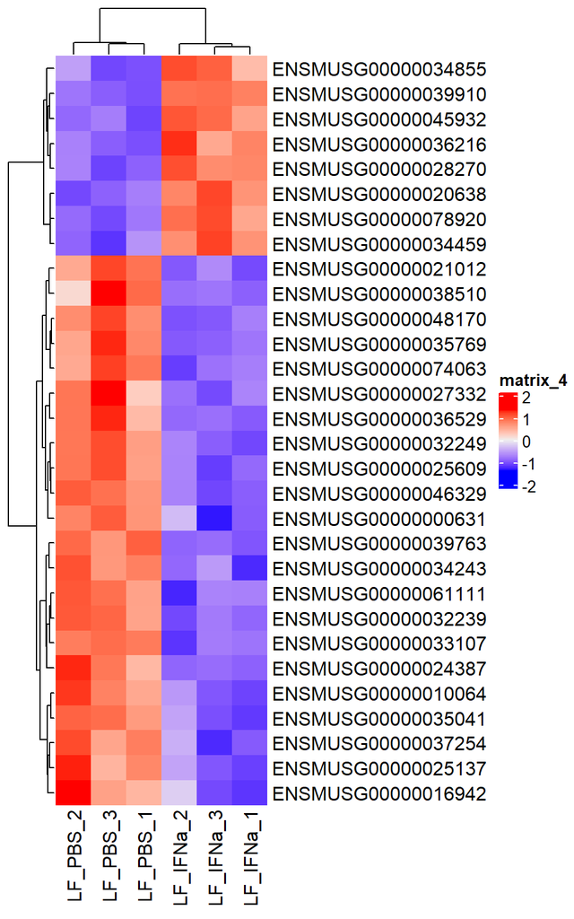

```r
expression_goi_scaled <- t(scale(t(expression_goi)))
Heatmap(expression_goi_scaled)
```

**2.11.4) Split the rows into up- and down-regulated genes using `row_split=ifelse…` in the heatmap function `Heatmap()`. Next, split the columns based on stimulus: `column_split = metadata$stimulus`**

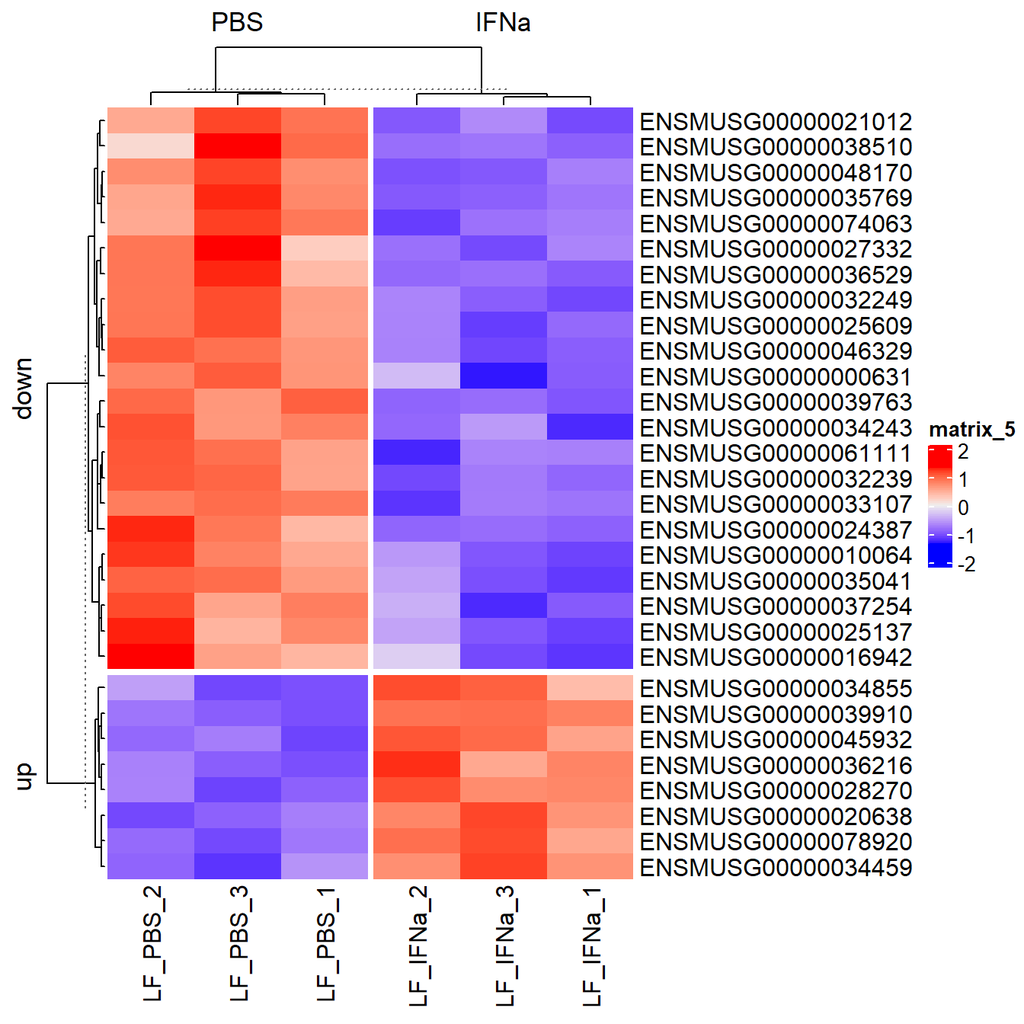

```r
Heatmap(
  expression_goi_scaled,
  row_split = ifelse(limmaRes[goi,]$logFC > 0, "up", "down"),
  column_split = metadata$stimulus
        )
```

**Enrichment analysis**

**Filter all genes with logFC > 0 from the table of significant genes and store their Ensembl IDs (as a vector) in the object goi. Next convert the ENSEMBL IDs to gene symbols.**

```r
limmaRes_up <- limmaResSig %>%
  filter(logFC > 0)
goi <- row.names(limmaRes_up)
glimpse(goi)
```

```
##  chr [1:24] "ENSMUSG00000020638" "ENSMUSG00000078920" "ENSMUSG00000036216" ...
```

```r
goi <- gmap[goi, ]$external_gene_name |> unique()
glimpse(goi)
```

```
##  chr [1:24] "Cmpk2" "Ifi47" "Leap2" "Cited2" "Ifit1" "Cxcl10" "Phf11a" ...
```

**Prepare the background/universe set**

```r
universe <- unique(gmap$external_gene_name)
universe <- unique(universe[!is.na(universe) & universe != ""])
```

**Perform Fisher’s exact test enrichment with the object MSigDBand and store the results in the table fisher_tb**

```r
MSigDB <- readRDS("MSigDB.rds")
fisher_tbl <- map_df(names(MSigDB), function(pw) {
  pw_genes <- MSigDB[[pw]]
  sig_genes <- goi
  overlap <- intersect(sig_genes, pw_genes)
  a <- length(overlap)
  b <- length(sig_genes) - a
  c <- length(pw_genes) - a
  d <- length(universe) - (a+b+c)

  ft <- fisher.test(matrix(c(a,b,c,d),2), alternative = "greater")

  tibble(
    pathway = pw,
    pvalue = ft$p.value,
    odds_ratio = as.numeric(ft$estimate),
    DE_in_pathway = a,
    overlapping_genes = paste(overlap, collapse = ",")
  )
})
```

Correct for multiple testing:

```r
fisher_tbl <-  mutate(fisher_tbl, p_adj = p.adjust(pvalue, "BH"))
```

And filter the results based on the top 30 significant hits:

```r
top_30 <- fisher_tbl %>%
  arrange(p_adj) %>%
  slice_head(n = 30)
```

**2.12) Now visualize the results based on the top 30 significant hits**

[figure not shown]

```r
ggplot(top_30, aes(
  x = log(odds_ratio),
  y = reorder(pathway, odds_ratio),
  size = -log10(p_adj),
  color = log2(odds_ratio)
)) +
  geom_point() +
  scale_size_continuous(name = "-log10(p_adj)") +
  scale_color_gradient(low = "lightblue", high = "darkblue", name = "log2(odds_ratio)") +
  labs(
    x = "log2(odds_Ratio)",
    y = "Pathway",
    title = "Top 30 Enriched Pathways"
  ) +
  theme_minimal(base_size = 12) +
  theme(
    axis.text.y = element_text(size = 10),
    plot.title = element_text(face = "bold", hjust = 0.5)
  )
```

**Final Questions**

**2.13) Looking at the correlation heatmap and MDS plot - do you see strong effects and clear differences between groups? Discuss the signal to noise ratio of this dataset.**

The **heatmap** suggests a moderate signal separating IFNa and PBS, but high variability within groups (while IFNa1 and IFNa3 are highly correlated, IFNa2 shows weaker correlation to the other IFNa samples, while the same happens with PBS).

This is also confirmed by the **MDS Plot**: There is a tendency of separation between IFNa and PBS samples along the X1 axis, but the samples PBS1 and IFNa2 do not follow this trend.

**`Heatmap(corMT)`:**

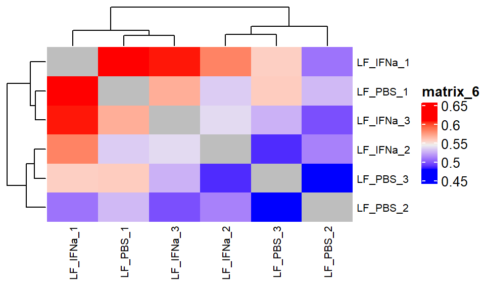

```r
Heatmap(corMT,
        row_names_gp = gpar(fontsize = 8),
        column_names_gp = gpar(fontsize = 8))
```

**`MDS Plot:`**

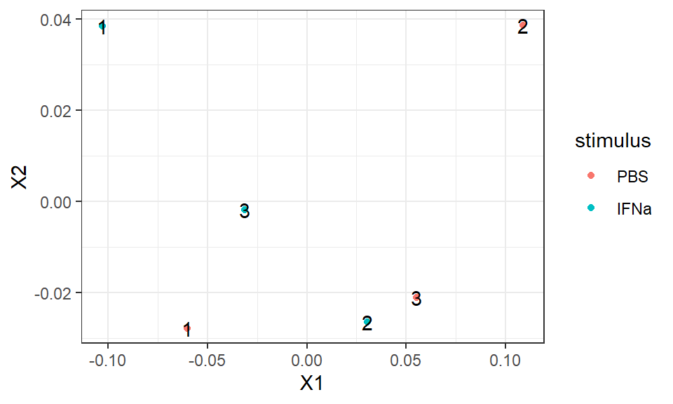

```r
data.frame(cmdscale(dist(2-corMT),eig=TRUE, k=2)$points) |>
  add_column(stimulus = metadata$stimulus) |>
  rownames_to_column("sample") |>
  mutate(sn = gsub("^.+?_(\\d)$", "\\1", sample)) |>  # This shortens the sample names to just the number at the end
  ggplot(aes(x=X1,y=X2)) +
  geom_point(aes(color=stimulus)) +
  geom_text(aes(label=sn)) +
  theme_bw()
```

**2.14) Do you trust the results of differential expression? Do the observed differences in the (normalized) data fit to the log fold changes and p-values obtained from the statistical tests?**

**Volcano map of differential gene expression:**

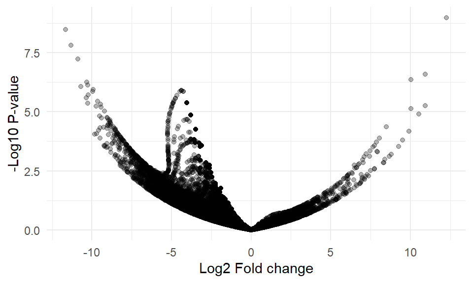

```r
ggplot(
  data = limmaRes,
  mapping = aes(x = logFC, y = -log10(P.Value))) +
  geom_point(alpha = 0.3) +
  theme_minimal() +
  labs(
    x = "Log2 Fold change",
    y = "-Log10 P-value"
  )
```

**Highest logFC values** in normalized data:

```r
limmaRes %>% arrange(desc(logFC)) %>% head(5) %>% select(logFC)
```

```
##                       logFC
## ENSMUSG00000020638 12.27273
## ENSMUSG00000034459 10.93990
## ENSMUSG00000078920 10.92211
## ENSMUSG00000034855 10.54059
## ENSMUSG00000036216 10.04286
```

**Lowest logFC values** in normalized data:

```r
limmaRes %>% arrange(logFC) %>% head(5) %>% select(logFC)
```

```
##                        logFC
## ENSMUSG00000010064 -11.64695
## ENSMUSG00000048170 -11.30042
## ENSMUSG00000035769 -10.88345
## ENSMUSG00000033107 -10.68755
## ENSMUSG00000025609 -10.36141
```

The volcano plot shows **many extreme logFCs**, i.e. points that distance themselves from the 0 in the x-axis.

This is **in accordance to the logFC values** from normalized data, which range from -11.646950 to 12.272730.

By filtering the normalized expression of genes with a logFC >10 and < -10, we can see that extreme logFC values represent a trend of overexpression in one condition accompanied by underexpression in the other (see below).

Thus, the results of differential expression are **trustworthy** since estimated log fold changes match (indicating reliability of the model), *as long as the data set is filtered by P-value distribution*.

```r
extreme_genes <- dataVoom$E[rownames(limmaRes %>% filter(logFC > 10 | logFC < -10)),
                           c("LF_IFNa_1","LF_IFNa_2","LF_IFNa_3","LF_PBS_1","LF_PBS_2","LF_PBS_3")]
expr <- as.data.frame(extreme_genes) %>%
  tibble::rownames_to_column(var = "gene") %>%
  pivot_longer(cols = -gene, names_to = "sample", values_to = "expression") %>%
  left_join(metadata %>% tibble::rownames_to_column(var="sample"), by = "sample")
```

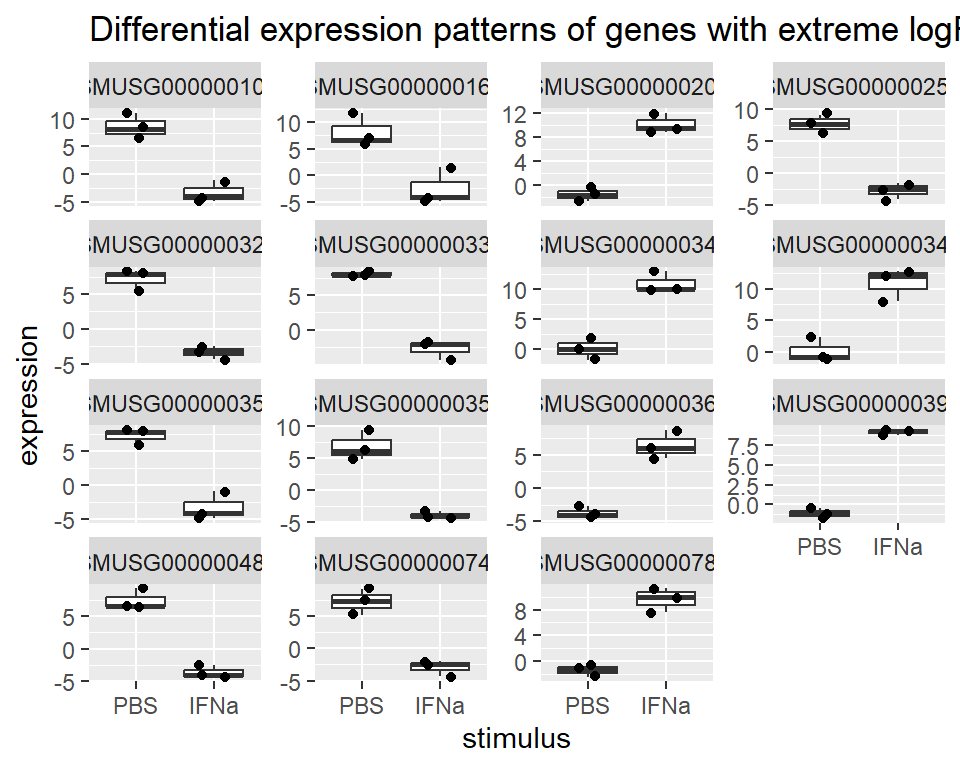

```r
ggplot(expr, aes(x = stimulus, y = expression)) +
  geom_boxplot() +
  geom_jitter(width = 0.2) +
  facet_wrap(~ gene, scales = "free_y") +
  labs(
    title = "Differential expression patterns of genes with extreme logFC")
```

**2.15) Looking at the enriched genes and pathways - are the results expected?**

[figure not shown]

```r
ggplot(top_30, aes(
  x = log(odds_ratio),
  y = reorder(pathway, odds_ratio),
  size = -log10(p_adj),
  color = log2(odds_ratio)
)) +
  geom_point() +
  scale_size_continuous(name = "-log10(p_adj)") +
  scale_color_gradient(low = "lightblue", high = "darkblue", name = "log2(odds_ratio)") +
  labs(
    x = "log2(odds_Ratio)",
    y = "Pathway",
    title = "Top 30 Enriched Pathways"
  ) +
  theme_minimal(base_size = 12) +
  theme(
    axis.text.y = element_text(size = 10),
    plot.title = element_text(face = "bold", hjust = 0.5)
  )
```

The graph shows the strongest and most significant enrichment for **interferon alpha and interferon gamma**.

This goes along with the hypothesis that IFN stimulation changes gene expression in liver fibroblasts, leading to other immune response-related pathways being also affected, although at a lower degree/significance (e.g. TNFa and IL6)